# Introduction to R for Data Science: Session 02: Introduction to Data Structures in R

Goran S. Milovanovic, Phd

October 13, 2018

# Introduction to R for Data Science

### Session 02: Introduction to Data Structures in R

10/13/2018, Belgrade, Serbia

Organized by: Dr Goran S. Milovanović and [Startit](http://en.startit.rs)

## Lecturer

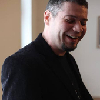

[Goran S. Milovanović](http://www.exactness.net), Phd

Owner, [DataKolektiv](https://www.linkedin.com/company/18515547); Data Scientist for [Wikidata](https://www.wikidata.org) at [WMDE](https://wikimedia.de/); Data Science Mentor at [Springboard](https://www.springboard.com/workshops/data-science)

### A. Data Types in R, Subsetting, and Coercion

We are first going to introduce the elementary data types. Along the way, we will see how to work with various data structures in R, starting from simpler structures that encompas elements of one data type only (vectors and matrices), and towards the more complex objects that can handle multiple data types - like lists and data frames.

```r
# - libraries
library(datasets)
# - Let's start with some vectors:
char_vect <- character(length = 0) # - empty character vect
char_vect
```

```
character(0)
```

Zero-length vectors is the R default on vector creation: use `character(n)` or `character(length=n)` to create a vector of length n. Do not forget: unlike many other programming languages, **vector indexing in R starts from one (1)**, so the first element of your vector is `vector[1]`!

```r
num_vect <- numeric(length = 10) # length can be != 0, but 0 is default value
num_vect
```

```
 [1] 0 0 0 0 0 0 0 0 0 0
```

All zeroes, but length == 10. Let’s meet the logical type:

```r
log_vect <- logical(length = 3) # default value is FALSE
log_vect
```

```
[1] FALSE FALSE FALSE
```

The default value for numeric vectors is `0`, while for logical vectors is `FALSE`. You always need to type capital letters to adress logical constants of `FALSE` and `TRUE` in R, respectively, but you can abbreviate logicals as `T` or `F` (capital letters again!)

Let’s learn about `c()`:

```r
# c() is commonly used to create vectors
num_vect_2 <- c(1, 14, 2, NA, 999, 101) # numerics
num_vect_2
```

```
[1]   1  14   2  NA 999 101
```

We use `c()` a lot in R. Obviously, it is an in-built function, and what it does is called *concatenation*. For now, think of vector concatenation simply as of “putting things together in a new vector”:

```r
log_vect_2 <- c(TRUE, FALSE, FALSE, TRUE, TRUE, TRUE) # put some logicals together
log_vect_2 # in a new vector called log_vect2
```

```
[1]  TRUE FALSE FALSE  TRUE  TRUE  TRUE
```

Concatenating characters: **do not** confuse this with string concatenation in other programming languages:

```r
char_vect_2 <- c("this", "is", "a", "data", "science", "workshop") # characters
char_vect_2
```

```
[1] "this"     "is"       "a"        "data"     "science"  "workshop"
```

Function `length()` returns the size of the vector:

```r
# Some useful functions
length(char_vect)
```

```
[1] 0
```

Everything in R is an *object*. Objects have *classes*, which is not the same as the type of the data. To ask R what class does a particular object belongs to, do `class(object)`:

```r
class(num_vect)
```

```
[1] "numeric"
```

To learn about the data type, use `typeof()`:

```r
typeof(num_vect)
```

```
[1] "double"
```

And finally, we also have `mode9()`:

```r
mode(num_vect)
```

```
[1] "numeric"
```

The difference between `typeof()` and `mode()` reside on a rather deep level of the structure of R as a programming language. At this point, it is not really relevant for us. To learn more check out [this](https://stackoverflow.com/questions/35445112/what-is-the-difference-between-mode-and-class-in-r) Stack Overflow discussion.

There are many “utilities” in {base}. For example, `duplicate()` will return TRUE wherever a vector element is a duplicate of some element that has appearead before, and FALSE wherever an element occurs for the first time:

```r
duplicated(log_vect_2)
```

```
[1] FALSE FALSE  TRUE  TRUE  TRUE  TRUE
```

`is.something()` family of functions is very important:

```r
# More useful functions
is.numeric(num_vect)
```

```
[1] TRUE
```

```r
is.character(num_vect)
```

```
[1] FALSE
```

```r
as.logical(num_vect)
```

```
 [1] FALSE FALSE FALSE FALSE FALSE FALSE FALSE FALSE FALSE FALSE
```

```r
is.na(num_vect_2)
```

```
[1] FALSE FALSE FALSE  TRUE FALSE FALSE
```

```r
# "is.x" functions check if something is x or not.
# Replace x with numeric, character, NA, etc.
```

All `is.something()` functions return logicals (`TRUE` or `FALSE`): `is.numeric()`, `is.na`, etc. All `as.something()` functions in R will attempt at a type conversion: `as.character(5)` will produce `"5"`, an object for which `is.character("5") == T`.

Now, how do we access vector components: a single vector element, or a range of elements?

```r
# Vector subsetting in R
char_vect_2[4] # select single element
```

```
[1] "data"
```

```r
log_vect_2[1:3] # or some interval
```

```
[1]  TRUE FALSE FALSE
```

```r
num_vect_2[3:length(num_vect_2)] # or use length() function to select an interval
```

```
[1]   2  NA 999 101
```

```r
# New objects can be created when subsetting
test <- num_vect_2[-c(3,4)] # gives all except 3rd and 4th element
test
```

```
[1]   1  14 999 101
```

Some operators in R are enclosed by the percent sign `%`, like `%in%`:

```r
test_2 <- num_vect_2 %in% test # operator %in% can be very useful
test_2
```

```
[1]  TRUE  TRUE FALSE FALSE  TRUE  TRUE
```

Later on, we will learn about `%`, `%>%`, and similarly looking things. NOTE: They do not bear any *semantic* similarity necessarily.

```r
not_na <- num_vect_2[!is.na(num_vect_2)] # removing NAs
not_na
```

```
[1]   1  14   2 999 101
```

Vector sorting in R with `sort()` function:

```r
# Vector ordering
sort(test, decreasing = T) # using sort() function
```

```
[1] 999 101  14   1
```

Or we can use `order()`:

```r
test[order(test, decreasing = T)] # or with order() function
```

```
[1] 999 101  14   1
```

The difference between `sort()` and `order()`:

```r
# The difference between sort() and order():
someVector <- c(7,8,1,2)
sort(someVector, decreasing = T) # returns a vector sorted
```

```
[1] 8 7 2 1
```

In R, `sort()` returns the input vector sorted, while `order()` returns the indices by which the input vector should be sorted:

```r
order(someVector, decreasing = T)
```

```
[1] 2 1 4 3
```

Producing vector sequences:

```r
# Vector sequences
seq(1, 22,by = 2) # seq is for "sequence"
```

```
 [1]  1  3  5  7  9 11 13 15 17 19 21
```

With `rep()`:

```r
rep(1, 4) # rep means: "replicate"
```

```
[1] 1 1 1 1
```

```r
num_vect_2
```

```
[1]   1  14   2  NA 999 101
```

```r
rep(num_vect_2, 2) # replicate num_vect_2, 2 times
```

```
 [1]   1  14   2  NA 999 101   1  14   2  NA 999 101
```

Again, producing vectors by concatenation:

```r
# Concatenation
new_num_vect <- c(num_vect, num_vect_2) # using 2 vectors to create new one
new_num_vect
```

```
 [1]   0   0   0   0   0   0   0   0   0   0   1  14   2  NA 999 101
```

Be very, very careful when it comes to **coercion** in R: a forcefull change of data type.

```r
new_combo_vect <- c(num_vect_2, log_vect) # combination of num and log vector
new_combo_vect # all numbers? false to zero? coercion in action
```

```
[1]   1  14   2  NA 999 101   0   0   0
```

Coercing *numeric* (“younger”) to *character* (“older”) data type:

```r
new_combo_vect_2 <- c(char_vect_2, num_vect_2) #works as well
new_combo_vect_2 # where are the numbers?
```

```
 [1] "this"     "is"       "a"        "data"     "science"  "workshop" "1"        "14"       "2"        NA
[11] "999"      "101"
```

```r
class(new_combo_vect_2) # all characters: coercion in R
```

```
[1] "character"
```

Coercion order in R is as follows (reading “<” as “under coercion becomes” from right to the left): *logical* < *integer* < *numeric* < *complex* < *character* < *list*.

### B. Matrices

Matrix is a special kind of vector with dimension of two. One way to produce a matrix in R is to use the `matrix()` function:

```r
# Matrices in R
matr <- matrix(data = c(1, 3, 5, 7, NA, 11),
               nrow = 2,
               ncol = 3) # 2x3 matrix
matr
```

```
     [,1] [,2] [,3]
[1,]    1    5   NA
[2,]    3    7   11
```

Vectors in R are **dimensionless**; matrices, as mentioned, have a dimension of two:

```r
dim(c(1, 2, 2, 4))
```

[output not shown]

```r
dim(matr)
```

```
[1] 2 3
```

R also supports the `array` type, which represents vectors that can have more than two dimensions; we will not study arrays here. Please mind the difference between the class of the matrix object and its type:

```r
class(matr) # yes, it's a matrix
```

```
[1] "matrix"
```

```r
typeof(matr) # double as expected
```

```
[1] "double"
```

In R, vectors, matrices, and arrays can encompass elements (components) of only one data type. Lists in R (see below) can encompass elements of different data types. Let’s start subsetting matrices:

```r
matr[,2] # 2nd column
```

```
[1] 5 7
```

```r
# This will produce an error:
# matr[3,] # oops, out of bounds, there's no 3rd row
```

```r
matr[2,3] # element in 2nd row and 3rd column
```

```
[1] 11
```

```r
matr_2 <- matrix(data = c(1, 3, 5,"7", NA, 11),
                 nrow = 2,
                 ncol = 3) # another 2x3 matrix
```

```r
class(matr_2) # matrix again
```

```
[1] "matrix"
```

```r
typeof(matr_2) # but not double anymore, type conversion in action!
```

```
[1] "character"
```

```r
t(matr_2) # transponed matr_2
```

```
     [,1] [,2]
[1,] "1"  "3"
[2,] "5"  "7"
[3,] NA   "11"
```

### C. Scalar vs. Vector Operators in R

R is a [vector programming language](https://en.wikipedia.org/wiki/Array_programming), which brings unique power to handle problems in technical computation, especially mathematical statistics and Data Science. If you have never encountered the concept of vector programming before, it would be useful to do some reading at this point. For example, this short introduction by Noam Ross will explain what vectorization is and why is it used in languages like R: [Vectorization in R: Why?](http://www.noamross.net/blog/2014/4/16/vectorization-in-r--why.html).

Let’s take a closer look at vector arithmetics and algebra in R.

```r
arr1 <- seq(2,20,2)
arr2 <- seq(1,19,2)
```

If we simply use the multiplicaton operator as usual, like in `a*b`, R will perform an element-wise multiplication of two vectors:

```r
# get vectorized in R: element-wise multiplication:
arr1 * arr2
```

```
 [1]   2  12  30  56  90 132 182 240 306 380
```

`+`, `-`, `/`, `^` and similar all operate element-wise over vectors when used in a traditional way:

```r
# similar:
arr1 + arr2
```

```
 [1]  3  7 11 15 19 23 27 31 35 39
```

```r
arr1 - arr2
```

```
 [1] 1 1 1 1 1 1 1 1 1 1
```

```r
arr1 / arr2
```

```
 [1] 2.000000 1.333333 1.200000 1.142857 1.111111 1.090909 1.076923 1.066667 1.058824 1.052632
```

```r
arr1 ^ arr2
```

```
 [1] 2.000000e+00 6.400000e+01 7.776000e+03 2.097152e+06 1.000000e+09 7.430084e+11 7.937148e+14 1.152922e+18
 [9] 2.185912e+21 5.242880e+24
```

**Never forget** about *recylcing* in R. Example: we have one numeric of length 3 and the other of length 4:

```r
n1 <- c(1, 2, 3)
n2 <- c(4, 5, 6, 7)
n1 + n2
```

```
longer object length is not a multiple of shorter object length
```

```
[1] 5 7 9 8
```

Where does `8` come from in the resulting vector? It is the consequence of recycling: once the elements of the shorter vector have been exhausted, R started looping over it from the begining.

Now let’s see how to do elementary linear algebra in R.

```r
# scalar ("inner", "dot") product in R:
arr1 %*% arr2
```

```
     [,1]
[1,] 1430
```

In the previous line, we have used `%*%` instead of `*`. This is how you call for a vector product from R.

```r
# again:
t(arr1) %*% arr2
```

```
     [,1]
[1,] 1430
```

```r
# NOTE: see https://stat.ethz.ch/R-manual/R-devel/library/base/html/matmult.html
```

Relax: `t(arr1) %*% arr2` and `arr1 %*% arr2` lead to the same results since R has automatically (and silently) transposed the left vector in the later expression. You can use `crossprod()` to make this computation faster:

```r
crossprod(arr1,arr2) # faster
```

```
     [,1]
[1,] 1430
```

Since the result of this operation is returned as a matrix, we can use `drop()` to delete the dimension with one level only and get to a “scalar” value (N.B. There are no scalar values in R only; everything is a vector):

```r
# as scalar:
drop(crossprod(arr1, arr2))
```

```
[1] 1430
```

```r
# do: ?drop
```

What about multiplying x1 with transpose(x2)? The fast way:

```r
# tcrossproduct() in R:
arr1
```

```
 [1]  2  4  6  8 10 12 14 16 18 20
```

```r
t(arr2)
```

```
     [,1] [,2] [,3] [,4] [,5] [,6] [,7] [,8] [,9] [,10]
[1,]    1    3    5    7    9   11   13   15   17    19
```

```r
tcrossprod(arr1, arr2) # faster
```

```
      [,1] [,2] [,3] [,4] [,5] [,6] [,7] [,8] [,9] [,10]
 [1,]    2    6   10   14   18   22   26   30   34    38
 [2,]    4   12   20   28   36   44   52   60   68    76
 [3,]    6   18   30   42   54   66   78   90  102   114
 [4,]    8   24   40   56   72   88  104  120  136   152
 [5,]   10   30   50   70   90  110  130  150  170   190
 [6,]   12   36   60   84  108  132  156  180  204   228
 [7,]   14   42   70   98  126  154  182  210  238   266
 [8,]   16   48   80  112  144  176  208  240  272   304
 [9,]   18   54   90  126  162  198  234  270  306   342
[10,]   20   60  100  140  180  220  260  300  340   380
```

And here’s the less eficient way (leading to the same result, of course):

```r
# or:
arr1 %*% t(arr2) # slower
```

```
      [,1] [,2] [,3] [,4] [,5] [,6] [,7] [,8] [,9] [,10]
 [1,]    2    6   10   14   18   22   26   30   34    38
 [2,]    4   12   20   28   36   44   52   60   68    76
 [3,]    6   18   30   42   54   66   78   90  102   114
 [4,]    8   24   40   56   72   88  104  120  136   152
 [5,]   10   30   50   70   90  110  130  150  170   190
 [6,]   12   36   60   84  108  132  156  180  204   228
 [7,]   14   42   70   98  126  154  182  210  238   266
 [8,]   16   48   80  112  144  176  208  240  272   304
 [9,]   18   54   90  126  162  198  234  270  306   342
[10,]   20   60  100  140  180  220  260  300  340   380
```

```r
# And we now learned that R defaults to...
arr1
```

```
 [1]  2  4  6  8 10 12 14 16 18 20
```

```r
# ... column vectors - because only this is a row vector:
t(arr1)
```

```
     [,1] [,2] [,3] [,4] [,5] [,6] [,7] [,8] [,9] [,10]
[1,]    2    4    6    8   10   12   14   16   18    20
```

Let’s practice multiplying vectors and matrices a bit:

```r
# Multplying vectors and matrices
arr1 <- 1:4
arr1
```

```
[1] 1 2 3 4
```

```r
arr2 <- matrix(rep(1:4,4),ncol = 4,byrow = T)
arr2
```

```
     [,1] [,2] [,3] [,4]
[1,]    1    2    3    4
[2,]    1    2    3    4
[3,]    1    2    3    4
[4,]    1    2    3    4
```

```r
arr1 * arr2 # element-wise
```

```
     [,1] [,2] [,3] [,4]
[1,]    1    2    3    4
[2,]    2    4    6    8
[3,]    3    6    9   12
[4,]    4    8   12   16
```

```r
# crossprod()
arr1 %*% arr2
```

```
     [,1] [,2] [,3] [,4]
[1,]   10   20   30   40
```

```r
t(arr1)
```

```
     [,1] [,2] [,3] [,4]
[1,]    1    2    3    4
```

```r
arr2
```

```
     [,1] [,2] [,3] [,4]
[1,]    1    2    3    4
[2,]    1    2    3    4
[3,]    1    2    3    4
[4,]    1    2    3    4
```

```r
t(arr1) %*% arr2
```

```
     [,1] [,2] [,3] [,4]
[1,]   10   20   30   40
```

```r
crossprod(arr1, arr2)
```

```
     [,1] [,2] [,3] [,4]
[1,]   10   20   30   40
```

```r
# tcrossprod()
arr1 %*% t(arr2)
```

```
     [,1] [,2] [,3] [,4]
[1,]   30   30   30   30
```

```r
arr1
```

```
[1] 1 2 3 4
```

```r
t(arr2)
```

```
     [,1] [,2] [,3] [,4]
[1,]    1    1    1    1
[2,]    2    2    2    2
[3,]    3    3    3    3
[4,]    4    4    4    4
```

```r
tcrossprod(arr1, arr2)
```

```
     [,1] [,2] [,3] [,4]
[1,]   30   30   30   30
```

```r
# Multiplying matrices
arr1 <- matrix(rep(2,16),ncol = 4,byrow = T)
arr1
```

```
     [,1] [,2] [,3] [,4]
[1,]    2    2    2    2
[2,]    2    2    2    2
[3,]    2    2    2    2
[4,]    2    2    2    2
```

```r
# element-wise:
arr1 * arr2
```

```
     [,1] [,2] [,3] [,4]
[1,]    2    4    6    8
[2,]    2    4    6    8
[3,]    2    4    6    8
[4,]    2    4    6    8
```

```r
# t(arr1) %*% arr2
crossprod(arr1,arr2)
```

```
     [,1] [,2] [,3] [,4]
[1,]    8   16   24   32
[2,]    8   16   24   32
[3,]    8   16   24   32
[4,]    8   16   24   32
```

```r
# and this does the same:
arr1 %*% arr2
```

```
     [,1] [,2] [,3] [,4]
[1,]    8   16   24   32
[2,]    8   16   24   32
[3,]    8   16   24   32
[4,]    8   16   24   32
```

```r
tcrossprod(arr1,arr2)
```

```
     [,1] [,2] [,3] [,4]
[1,]   20   20   20   20
[2,]   20   20   20   20
[3,]   20   20   20   20
[4,]   20   20   20   20
```

```r
# which is, again, the same as:
arr1 %*% t(arr2)
```

```
     [,1] [,2] [,3] [,4]
[1,]   20   20   20   20
[2,]   20   20   20   20
[3,]   20   20   20   20
[4,]   20   20   20   20
```

You can use `%o% to produce an *outer product* of two vectors:

```r
# If a and b are two numeric arrays, their outer product is an array
# whose dimension vector is obtained by concatenating their two dimension
# vectors (order is important), and whose data vector is got by forming
# all possible products of elements of the data vector of a with those of b.
# [source: https://cran.r-project.org/doc/manuals/r-patched/R-intro.html#The-outer-product-of-two-arrays]
```

```r
# outter product of two vectors:
a <- 1:4
b <- 1:3
a %o% b
```

```
     [,1] [,2] [,3]
[1,]    1    2    3
[2,]    2    4    6
[3,]    3    6    9
[4,]    4    8   12
```

```r
# or:
outer(a,b,"*")
```

```
     [,1] [,2] [,3]
[1,]    1    2    3
[2,]    2    4    6
[3,]    3    6    9
[4,]    4    8   12
```